# Week 12 Student Lab: Image Classification & Land Cover Mapping — ARIA v8.0

## 學生實作筆記本

延續 W8–W10 的 STAC API 工作流程，本週進入影像分類與土地覆蓋製圖。

- **Lab 1:** K-means 非監督式分類
- **Lab 2:** Random Forest 監督式分類
- **應用情境:** 2024 花蓮地震後崩塌地偵測與面積估算

### 使用說明

- 標記為 **COMPLETE** 的儲存格已預先填好，直接執行即可。
- 標記為 `# ── COMPLETED ──` 的區塊需要你完成程式碼。
- 原本的練習提示已保留，並已依提示完成。
- 完成後依序執行所有儲存格，觀察輸出結果。

```python
# =============================================================================
# [S1] 環境設定 + STAC API 連線 + 研究區域定義 【COMPLETE — 直接執行】
# =============================================================================

# --- 基本套件 ---
import numpy as np
import pandas as pd
import matplotlib.pyplot as plt
import matplotlib.colors as mcolors
from matplotlib.patches import Patch
import warnings
warnings.filterwarnings('ignore')

# --- 中文字型設定（跨平台：Colab / Windows / macOS 皆適用）---
import matplotlib.font_manager as fm
try:
    import subprocess
    subprocess.run(["apt-get", "-qq", "install", "-y", "fonts-noto-cjk"],
                   capture_output=True)
    fm._load_fontmanager(try_read_cache=False)
except FileNotFoundError:
    pass  # 非 Linux（Windows / macOS），跳過 apt-get
_cjk_candidates = [
    "Microsoft JhengHei",      # Windows 正黑體
    "PingFang TC",             # macOS 蘋方
    "Noto Sans CJK TC",       # Colab / Linux
    "Heiti TC",                # macOS 黑體
    "WenQuanYi Micro Hei",    # Linux
    "Droid Sans Fallback",    # Android / 舊 Linux
]
_available = {f.name for f in fm.fontManager.ttflist}
_cjk_found = [f for f in _cjk_candidates if f in _available]
if _cjk_found:
    plt.rcParams["font.sans-serif"] = _cjk_found + ["DejaVu Sans"]
    print(f"中文字型: {_cjk_found[0]}")
else:
    print("⚠️ 未找到中文字型，中文標題可能顯示為方框")
plt.rcParams["axes.unicode_minus"] = False
plt.rcParams["figure.dpi"] = 110

# --- STAC / 遙測資料載入 ---
import pystac_client
import planetary_computer
import stackstac

# --- 機器學習 ---
from sklearn.cluster import KMeans
from sklearn.ensemble import RandomForestClassifier
from sklearn.metrics import (
    confusion_matrix,
    classification_report,
    accuracy_score,
    cohen_kappa_score,
)
from sklearn.model_selection import train_test_split

# --- 影像後處理 ---
from scipy.ndimage import median_filter

# --- GIS / 向量處理（ROI 多邊形 → 像素遮罩）---
import geopandas as gpd
from shapely.geometry import Polygon
from rasterio.features import rasterize
from rasterio.transform import Affine
import pyproj
import zipfile, xml.etree.ElementTree as ET  # KMZ 解析用

print("所有套件載入成功！")

# --- 連線 Planetary Computer STAC API ---
catalog = pystac_client.Client.open(
    "https://planetarycomputer.microsoft.com/api/stac/v1",
    modifier=planetary_computer.sign_inplace,
)
print("STAC API 連線成功:", catalog.title)

# --- 研究區域：花蓮市周邊（2024 地震災區）---
# 東邊界擴大至 121.6、北邊界至 23.77，以涵蓋近海水體樣本區
HUALIEN_BBOX = [121.2574, 23.6546, 121.6, 23.77]

print(f"研究區域 BBOX: {HUALIEN_BBOX}")
print(f"經度範圍: {HUALIEN_BBOX[0]:.4f} ~ {HUALIEN_BBOX[2]:.4f}")
print(f"緯度範圍: {HUALIEN_BBOX[1]:.4f} ~ {HUALIEN_BBOX[3]:.4f}")
```

```
中文字型: Microsoft JhengHei
```

```
所有套件載入成功！
```

```
STAC API 連線成功: Microsoft Planetary Computer STAC API
研究區域 BBOX: [121.2574, 23.6546, 121.6, 23.77]
經度範圍: 121.2574 ~ 121.6000
緯度範圍: 23.6546 ~ 23.7700
```

```python
# =============================================================================
# [S2] 搜尋 Sentinel-2 震後影像 【COMPLETE — 直接執行】
# =============================================================================

from datetime import datetime, timezone
from types import SimpleNamespace

# 漸進式搜尋：先嚴格，找不到就自動放寬
# （花蓮 4-5 月是梅雨季，雲量高，需要彈性搜尋策略）
search_configs = [
    ("2024-04-15/2024-05-31", 20, "Phase 1: 震後 2 個月，雲量 < 20%"),
    ("2024-04-03/2024-08-31", 30, "Phase 2: 震後 5 個月，雲量 < 30%"),
    ("2024-04-03/2024-12-31", 50, "Phase 3: 震後全年，雲量 < 50%"),
    ("2024-01-01/2024-12-31", 70, "Phase 4: 2024 全年，雲量 < 70%"),
]

# 已完成檢核後固定的備援影像。若 STAC 搜尋服務暫時逾時，仍可完成本周分類流程。
PINNED_ITEM_ID = "S2A_MSIL2A_20240827T022531_R046_T51QUG_20240827T053853"
PINNED_ITEM_DATETIME = datetime(2024, 8, 27, 2, 25, 31, tzinfo=timezone.utc)
PINNED_ITEM_CLOUD = 8.358254
PINNED_PREFIX = (
    "https://sentinel2l2a01.blob.core.windows.net/sentinel2-l2/51/Q/UG/2024/08/27/"
    "S2A_MSIL2A_20240827T022531_N0511_R046_T51QUG_20240827T053853.SAFE/"
    "GRANULE/L2A_T51QUG_A047948_20240827T023722/IMG_DATA"
)
PINNED_ASSET_URLS = {
    "B02": f"{PINNED_PREFIX}/R10m/T51QUG_20240827T022531_B02_10m.tif",
    "B03": f"{PINNED_PREFIX}/R10m/T51QUG_20240827T022531_B03_10m.tif",
    "B04": f"{PINNED_PREFIX}/R10m/T51QUG_20240827T022531_B04_10m.tif",
    "B08": f"{PINNED_PREFIX}/R10m/T51QUG_20240827T022531_B08_10m.tif",
    "B11": f"{PINNED_PREFIX}/R20m/T51QUG_20240827T022531_B11_20m.tif",
    "B12": f"{PINNED_PREFIX}/R20m/T51QUG_20240827T022531_B12_20m.tif",
    "SCL": f"{PINNED_PREFIX}/R20m/T51QUG_20240827T022531_SCL_20m.tif",
}


def use_pinned_item(reason):
    print(f"  ⚠️ STAC 搜尋暫時無法完成：{reason}")
    print("  → 改用已檢核的固定影像，確保 notebook 可重現執行。")
    return SimpleNamespace(
        id=PINNED_ITEM_ID,
        datetime=PINNED_ITEM_DATETIME,
        properties={"eo:cloud_cover": PINNED_ITEM_CLOUD, "platform": "Sentinel-2A"},
        assets=PINNED_ASSET_URLS,
    )


items = None
best_item = None
USE_PINNED_ASSETS = False

for dt_range, max_cc, desc in search_configs:
    print(f"嘗試 {desc}...")
    try:
        search = catalog.search(
            collections=["sentinel-2-l2a"],
            bbox=HUALIEN_BBOX,
            datetime=dt_range,
            query={"eo:cloud_cover": {"lt": max_cc}},
            sortby=[{"field": "properties.eo:cloud_cover", "direction": "asc"}],
            limit=20,
            max_items=20,
        )
        items = search.item_collection()
        print(f"  → 找到 {len(items)} 景影像")
    except Exception as exc:
        best_item = use_pinned_item(f"{type(exc).__name__}: {exc}")
        USE_PINNED_ASSETS = True
        break

    if len(items) > 0:
        break

if best_item is None:
    if items is None or len(items) == 0:
        best_item = use_pinned_item("搜尋條件內無可用影像或服務未回應")
        USE_PINNED_ASSETS = True
    else:
        items_sorted = sorted(items, key=lambda x: x.properties["eo:cloud_cover"])
        best_item = items_sorted[0]

print("\n=== 選取的最佳影像 ===")
print(f"  影像 ID    : {best_item.id}")
print(f"  拍攝日期  : {best_item.datetime.strftime('%Y-%m-%d %H:%M:%S')}")
print(f"  雲量      : {best_item.properties['eo:cloud_cover']:.1f}%")
print(f"  平台      : {best_item.properties.get('platform', 'N/A')}")
print(f"  可用波段  : {list(best_item.assets.keys())[:10]}...")
```

```
嘗試 Phase 1: 震後 2 個月，雲量 < 20%...
```

```
  → 找到 0 景影像
嘗試 Phase 2: 震後 5 個月，雲量 < 30%...
```

```
  → 找到 10 景影像

=== 選取的最佳影像 ===
  影像 ID    : S2A_MSIL2A_20240827T022531_R046_T51QUG_20240827T053853
  拍攝日期  : 2024-08-27 02:25:31
  雲量      : 8.4%
  平台      : Sentinel-2A
  可用波段  : ['AOT', 'B01', 'B02', 'B03', 'B04', 'B05', 'B06', 'B07', 'B08', 'B09']...
```

```python
# =============================================================================
# [S3] 載入 6 波段 + SCL 雲遮罩 【COMPLETE — 直接執行】
# =============================================================================

# 選用 6 個反射率波段 + SCL（Scene Classification Layer）用於雲遮罩
BANDS_ALL = ["B02", "B03", "B04", "B08", "B11", "B12", "SCL"]
BANDS = ["B02", "B03", "B04", "B08", "B11", "B12"]  # 分類用的 6 波段
BAND_NAMES = ["Blue", "Green", "Red", "NIR", "SWIR1", "SWIR2"]

import rasterio
from rasterio.warp import reproject, Resampling


def asset_href(item, band):
    asset = item.assets[band]
    return asset.href if hasattr(asset, "href") else asset


def signed_asset_url(item, band):
    return planetary_computer.sign_url(asset_href(item, band))


print("正在簽章並載入 Sentinel-2 COG 影像，請稍候...")

# 目標格網：UTM 51N、20 m，和課堂設定一致。
target_crs = "EPSG:32651"
target_resolution = 20
transformer_bbox = pyproj.Transformer.from_crs("EPSG:4326", target_crs, always_xy=True)
x0, y0 = transformer_bbox.transform(HUALIEN_BBOX[0], HUALIEN_BBOX[1])
x1, y1 = transformer_bbox.transform(HUALIEN_BBOX[2], HUALIEN_BBOX[3])
xmin, xmax = sorted([x0, x1])
ymin, ymax = sorted([y0, y1])

n_cols = int(np.ceil((xmax - xmin) / target_resolution))
n_rows = int(np.ceil((ymax - ymin) / target_resolution))
img_transform = Affine(target_resolution, 0, xmin,
                       0, -target_resolution, ymax)

print(f"目標陣列形狀: (1, {len(BANDS_ALL)}, {n_rows}, {n_cols})  (time, band, y, x)")

img_layers = []
for band in BANDS_ALL:
    url = signed_asset_url(best_item, band)
    resampling = Resampling.nearest if band == "SCL" else Resampling.bilinear
    dest = np.full((n_rows, n_cols), np.nan, dtype=np.float64)
    with rasterio.Env(GDAL_DISABLE_READDIR_ON_OPEN="EMPTY_DIR",
                      CPL_VSIL_CURL_ALLOWED_EXTENSIONS=".tif"):
        with rasterio.open(url) as src:
            reproject(
                source=rasterio.band(src, 1),
                destination=dest,
                src_transform=src.transform,
                src_crs=src.crs,
                src_nodata=src.nodata,
                dst_transform=img_transform,
                dst_crs=target_crs,
                dst_nodata=np.nan,
                resampling=resampling,
            )
    img_layers.append(dest)
    print(f"  ✓ {band} loaded")

img_all = np.stack(img_layers, axis=0)

# --- 分離 SCL 與反射率波段 ---
scl = img_all[-1]             # 最後一個波段 = SCL
img = img_all[:-1] / 10000.0  # 前 6 波段轉為反射率

# --- SCL 雲遮罩 ---
# SCL 值定義（Sentinel-2 L2A）：
#   3 = Cloud Shadow, 8 = Cloud (medium prob), 9 = Cloud (high prob), 10 = Cirrus
cloud_mask = np.isin(scl, [3, 8, 9, 10])
n_cloud = int(np.sum(cloud_mask))
n_total = cloud_mask.size
print(f"\n=== SCL 雲遮罩 ===")
print(f"  雲/雲影像素: {n_cloud:,} / {n_total:,} ({n_cloud/n_total*100:.1f}%)")

# 套用雲遮罩（雲像素設為 NaN）
img[:, cloud_mask] = np.nan

# 將其他無效值（<= 0 或 > 1）也設為 NaN
img = np.where((img <= 0) | (img > 1), np.nan, img)

n_bands, n_rows, n_cols = img.shape

print(f"\n影像形狀: {img.shape}  (bands, height, width)")
print(f"像素大小: 20m x 20m")
print(f"影像尺寸: {n_cols * 20 / 1000:.1f} km x {n_rows * 20 / 1000:.1f} km")
print(f"有效像素比例（去雲後）: {np.sum(~np.isnan(img[0])) / img[0].size * 100:.1f}%")

for i, name in enumerate(BAND_NAMES):
    valid = img[i][~np.isnan(img[i])]
    if len(valid) > 0:
        print(
            f"  {name:6s} ({BANDS[i]}): "
            f"min={valid.min():.4f}, max={valid.max():.4f}, mean={valid.mean():.4f}"
        )

# 保存 UTM 座標資訊（後續 ROI 多邊形轉像素用）
x_coords = xmin + (np.arange(n_cols) + 0.5) * target_resolution
y_coords = ymax - (np.arange(n_rows) + 0.5) * target_resolution
x_res = float(target_resolution)
y_res = float(-target_resolution)
print(f"\nUTM Transform 已建立（供 ROI 多邊形柵格化使用）")
```

```
正在簽章並載入 Sentinel-2 COG 影像，請稍候...
目標陣列形狀: (1, 7, 620, 1754)  (time, band, y, x)
```

```
  ✓ B02 loaded
```

```
  ✓ B03 loaded
```

```
  ✓ B04 loaded
```

```
  ✓ B08 loaded
```

```
  ✓ B11 loaded
```

```
  ✓ B12 loaded
```

```
  ✓ SCL loaded

=== SCL 雲遮罩 ===
  雲/雲影像素: 105,216 / 1,087,480 (9.7%)

影像形狀: (6, 620, 1754)  (bands, height, width)
像素大小: 20m x 20m
影像尺寸: 35.1 km x 12.4 km
有效像素比例（去雲後）: 90.3%
  Blue   (B02): min=0.0957, max=0.9931, mean=0.1453
  Green  (B03): min=0.1033, max=0.9788, mean=0.1680
  Red    (B04): min=0.0996, max=0.9950, mean=0.1469
  NIR    (B08): min=0.0957, max=0.9862, mean=0.4095
  SWIR1  (B11): min=0.1087, max=0.9988, mean=0.2737
  SWIR2  (B12): min=0.1061, max=0.9811, mean=0.1893

UTM Transform 已建立（供 ROI 多邊形柵格化使用）
```

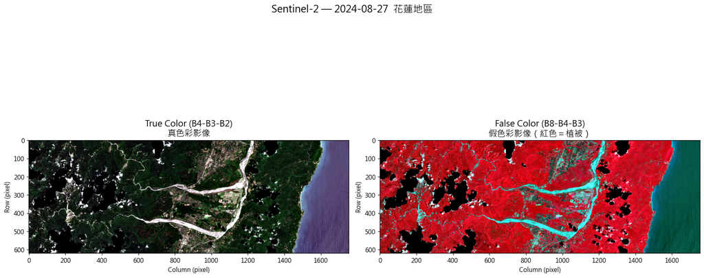

```python
# =============================================================================
# [S4] RGB 真色彩 + 假色彩視覺化 【COMPLETE — 直接執行】
# =============================================================================


def percentile_stretch(band, low=2, high=98):
    """百分位拉伸：增強影像對比度"""
    valid = band[~np.isnan(band)]
    if len(valid) == 0:
        return band
    vmin = np.percentile(valid, low)
    vmax = np.percentile(valid, high)
    stretched = (band - vmin) / (vmax - vmin + 1e-10)
    return np.clip(stretched, 0, 1)


def make_rgb(img_array, band_indices, low=2, high=98):
    """組合 RGB 影像並做百分位拉伸"""
    rgb = np.stack(
        [percentile_stretch(img_array[i], low, high) for i in band_indices],
        axis=-1,
    )
    return np.nan_to_num(rgb, nan=0)


# 波段索引: B02=0(Blue), B03=1(Green), B04=2(Red),
#           B08=3(NIR),  B11=4(SWIR1), B12=5(SWIR2)
true_color = make_rgb(img, [2, 1, 0])    # R=B04, G=B03, B=B02
false_color = make_rgb(img, [3, 2, 1])   # R=B08, G=B04, B=B03

fig, axes = plt.subplots(1, 2, figsize=(16, 8))

axes[0].imshow(true_color)
axes[0].set_title("True Color (B4-B3-B2)\n真色彩影像", fontsize=14)
axes[0].set_xlabel("Column (pixel)")
axes[0].set_ylabel("Row (pixel)")

axes[1].imshow(false_color)
axes[1].set_title(
    "False Color (B8-B4-B3)\n假色彩影像（紅色＝植被）", fontsize=14
)
axes[1].set_xlabel("Column (pixel)")
axes[1].set_ylabel("Row (pixel)")

plt.suptitle(
    f"Sentinel-2 — {best_item.datetime.strftime('%Y-%m-%d')}  花蓮地區",
    fontsize=16,
    y=1.02,
)
plt.tight_layout()
plt.show()
```

## Lab 1: K-means 非監督分類

### 非監督式分類：讓演算法自動發現影像中的光譜群組

K-means 不需要訓練資料，直接根據像素的光譜特徵進行分群。 我們使用 6 個波段作為特徵空間，觀察不同 K 值的分類結果。

**步驟：**

1. 視覺化特徵空間（NIR vs Red 散佈圖）
2. 執行 K-means 分類
3. 分析各群組的光譜特徵
4. 比較不同 K 值的結果

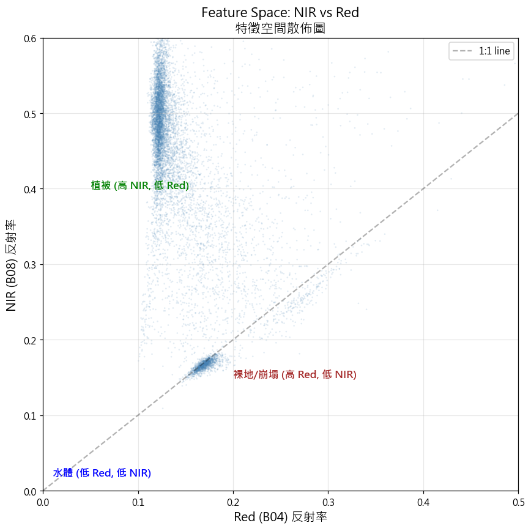

```
觀察：植被像素集中在左上方（高 NIR、低 Red），裸地/建物則靠近對角線。
這種分群結構就是 K-means 要找的 pattern。
```

```python
# =============================================================================
# [S6] 特徵空間視覺化 — NIR vs Red 散佈圖 【COMPLETED】
# =============================================================================

# 波段索引提示:
#   B02=0(Blue), B03=1(Green), B04=2(Red),
#   B08=3(NIR),  B11=4(SWIR1), B12=5(SWIR2)

# ── COMPLETED ──
# 從 img 陣列中取出 NIR 和 Red 波段，展平為一維陣列
# Hint: NIR 是第 3 個波段 (index=3)，Red 是第 2 個波段 (index=2)
nir_flat = img[3].flatten()     # B08 / NIR
red_flat = img[2].flatten()     # B04 / Red
# ── END COMPLETED ──

# 移除 NaN（已預先填好）
valid_mask_2d = ~(np.isnan(nir_flat) | np.isnan(red_flat))
nir_valid = nir_flat[valid_mask_2d]
red_valid = red_flat[valid_mask_2d]

# 隨機抽樣 10000 個像素（避免繪圖過慢）
np.random.seed(42)
n_sample = min(10000, len(nir_valid))
sample_idx = np.random.choice(len(nir_valid), size=n_sample, replace=False)

# 繪製散佈圖
fig, ax = plt.subplots(figsize=(8, 8))

# ── COMPLETED ──
# 使用 ax.scatter() 繪製散佈圖
# Hint: x 軸 = red_valid[sample_idx], y 軸 = nir_valid[sample_idx]
# Hint: 設定 c="steelblue", alpha=0.15, s=3, edgecolors="none"
ax.scatter(
    red_valid[sample_idx],   # x 軸：Red 反射率（抽樣後）
    nir_valid[sample_idx],   # y 軸：NIR 反射率（抽樣後）
    c="steelblue",
    alpha=0.15,
    s=3,
    edgecolors="none",
)
# ── END COMPLETED ──

ax.set_xlabel("Red (B04) 反射率", fontsize=13)
ax.set_ylabel("NIR (B08) 反射率", fontsize=13)
ax.set_title("Feature Space: NIR vs Red\n特徵空間散佈圖", fontsize=14)
ax.set_xlim(0, 0.5)
ax.set_ylim(0, 0.6)

# 標註典型區域
ax.annotate(
    "植被 (高 NIR, 低 Red)",
    xy=(0.05, 0.4),
    fontsize=11,
    color="green",
    fontweight="bold",
)
ax.annotate(
    "裸地/崩塌 (高 Red, 低 NIR)",
    xy=(0.2, 0.15),
    fontsize=11,
    color="brown",
    fontweight="bold",
)
ax.annotate(
    "水體 (低 Red, 低 NIR)",
    xy=(0.01, 0.02),
    fontsize=11,
    color="blue",
    fontweight="bold",
)

# 對角線（soil line 參考）
ax.plot([0, 0.5], [0, 0.5], "k--", alpha=0.3, label="1:1 line")
ax.legend()
ax.grid(True, alpha=0.3)
plt.tight_layout()
plt.show()

print("觀察：植被像素集中在左上方（高 NIR、低 Red），裸地/建物則靠近對角線。")
print("這種分群結構就是 K-means 要找的 pattern。")
```

```
總像素數    : 1,087,480
有效像素數  : 982,254
特徵維度    : 6 波段

正在執行 K-means (K=5)...
```

```
K-means 完成！ Inertia = 4038.38
```

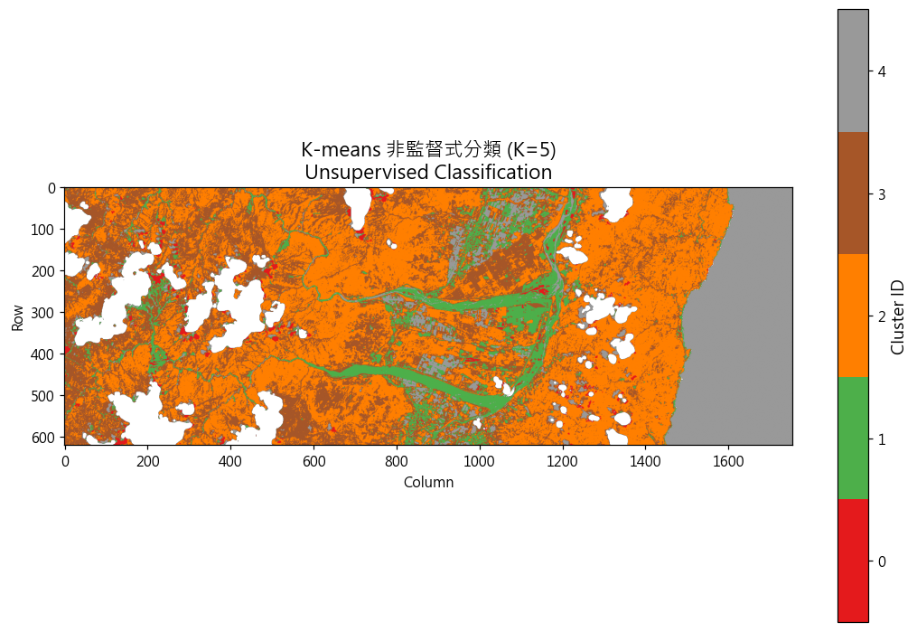

```
各群組像素統計:
  Cluster 0:   15,138 pixels (1.5%)
  Cluster 1:   85,799 pixels (8.7%)
  Cluster 2:  417,148 pixels (42.5%)
  Cluster 3:  283,116 pixels (28.8%)
  Cluster 4:  181,053 pixels (18.4%)
```

```python
# =============================================================================
# [S7] K-means 分類 (K=5) 【COMPLETED】
# =============================================================================

# --- 建立特徵矩陣（已預先填好）---
# 重塑為 (n_pixels, n_bands)
pixels = img.reshape(n_bands, -1).T  # shape: (n_pixels, 6)

# 找出有效像素（所有波段皆非 NaN）
valid_pixel_mask = ~np.any(np.isnan(pixels), axis=1)
pixels_valid = pixels[valid_pixel_mask]

print(f"總像素數    : {pixels.shape[0]:,}")
print(f"有效像素數  : {pixels_valid.shape[0]:,}")
print(f"特徵維度    : {pixels_valid.shape[1]} 波段")

# ── COMPLETED ──
# 1. 建立 KMeans 模型並進行分類
# Hint: KMeans(n_clusters=5, random_state=42, n_init=10, max_iter=300)
K = 5
print(f"\n正在執行 K-means (K={K})...")

kmeans = KMeans(n_clusters=K, random_state=42, n_init=10, max_iter=300)
labels_km = kmeans.fit_predict(pixels_valid)

print(f"K-means 完成！ Inertia = {kmeans.inertia_:.2f}")
# ── END COMPLETED ──

# --- 重建分類圖（已預先填好）---
class_map_km = np.full(pixels.shape[0], np.nan)
class_map_km[valid_pixel_mask] = labels_km
class_map_km = class_map_km.reshape(n_rows, n_cols)

# ── COMPLETED ──
# 2. 視覺化分類結果
# Hint: 使用 ax.imshow() 顯示 class_map_km
# Hint: 使用 plt.cm.get_cmap("Set1", K) 作為色彩映射
fig, ax = plt.subplots(figsize=(10, 8))
cmap_km = plt.cm.get_cmap("Set1", K)

im = ax.imshow(class_map_km, cmap=cmap_km, vmin=-0.5, vmax=K - 0.5)

cbar = plt.colorbar(im, ax=ax, ticks=range(K), shrink=0.8)
cbar.set_label("Cluster ID", fontsize=12)
ax.set_title(
    f"K-means 非監督式分類 (K={K})\nUnsupervised Classification", fontsize=14
)
ax.set_xlabel("Column")
ax.set_ylabel("Row")
plt.tight_layout()
plt.show()
# ── END COMPLETED ──

# 統計各群組像素數
print("\n各群組像素統計:")
for c in range(K):
    count = np.sum(labels_km == c)
    print(f"  Cluster {c}: {count:>8,} pixels ({count / len(labels_km) * 100:.1f}%)")
```

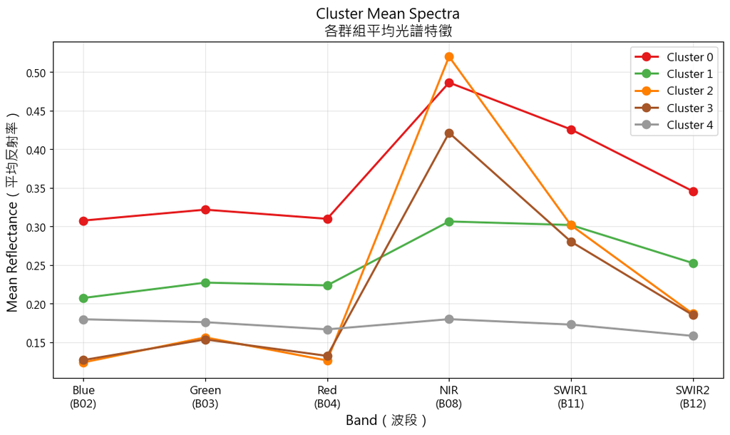

```
=== 光譜特徵判讀指引（檢查你的結果是否合理）===
  - NIR 高、Red 低 → 健康植被
  - 所有波段都低   → 水體
  - Red/SWIR 高    → 裸地 / 崩塌地
  - 整體偏亮       → 建物 / 人造地物

提示：如果你的圖中有一條曲線在 NIR 處有明顯高峰，那很可能是植被 cluster。
```

|  | Cluster | Blue | Green | Red | NIR | SWIR1 | SWIR2 | 推測地物 | 判讀依據 |
| --- | --- | --- | --- | --- | --- | --- | --- | --- | --- |
| 0 | 0 | 0.307613 | 0.321688 | 0.309833 | 0.486151 | 0.425583 | 0.345579 | 農地或稀疏植被 | NDVI=0.222 中等，植被訊號較弱 |
| 1 | 1 | 0.207398 | 0.227269 | 0.223667 | 0.306437 | 0.301796 | 0.252546 | 裸地 / 崩塌地 | NDVI=0.156 低，Red/SWIR 可見 |
| 2 | 2 | 0.124029 | 0.156353 | 0.126465 | 0.519748 | 0.301585 | 0.186868 | 森林或高覆蓋植被 | NDVI=0.609 高，NIR 明顯高於 Red |
| 3 | 3 | 0.127067 | 0.153738 | 0.132421 | 0.421135 | 0.280321 | 0.185269 | 森林或高覆蓋植被 | NDVI=0.522 高，NIR 明顯高於 Red |
| 4 | 4 | 0.179802 | 0.176087 | 0.166745 | 0.179966 | 0.172962 | 0.158311 | 裸地 / 崩塌地 | NDVI=0.038 低，Red/SWIR 可見 |

```python
# =============================================================================
# [S8] 各群組光譜特徵分析 【COMPLETED】
# =============================================================================

# 繪圖設定（已預先填好）
fig, ax = plt.subplots(figsize=(10, 6))
colors_spec = plt.cm.Set1(np.linspace(0, 1, K))

# ── COMPLETED ──
# 計算每個 cluster 的平均反射率，並繪製光譜曲線
# Hint: 對每個 cluster c (0 到 K-1)：
#   1. 用 pixels_valid[labels_km == c] 取出該 cluster 的像素
#   2. 用 .mean(axis=0) 計算平均光譜
#   3. 用 ax.plot() 繪製折線圖

cluster_means = np.zeros((K, n_bands))

for c in range(K):
    # 計算第 c 個 cluster 的平均反射率
    cluster_means[c] = pixels_valid[labels_km == c].mean(axis=0)

    # 繪製該 cluster 的光譜曲線
    ax.plot(
        range(n_bands),
        cluster_means[c],
        "o-",
        color=colors_spec[c],
        linewidth=2,
        markersize=8,
        label=f"Cluster {c}",
    )
# ── END COMPLETED ──

ax.set_xticks(range(n_bands))
ax.set_xticklabels(
    [f"{BAND_NAMES[i]}\n({BANDS[i]})" for i in range(n_bands)], fontsize=11
)
ax.set_ylabel("Mean Reflectance（平均反射率）", fontsize=13)
ax.set_xlabel("Band（波段）", fontsize=13)
ax.set_title("Cluster Mean Spectra\n各群組平均光譜特徵", fontsize=14)
ax.legend(fontsize=11, loc="upper right")
ax.grid(True, alpha=0.3)
plt.tight_layout()
plt.show()

# 答案驗證：預期光譜模式
print("\n=== 光譜特徵判讀指引（檢查你的結果是否合理）===")
print("  - NIR 高、Red 低 → 健康植被")
print("  - 所有波段都低   → 水體")
print("  - Red/SWIR 高    → 裸地 / 崩塌地")
print("  - 整體偏亮       → 建物 / 人造地物")
print("\n提示：如果你的圖中有一條曲線在 NIR 處有明顯高峰，那很可能是植被 cluster。")

def infer_cluster_landcover(mean_spectrum):
    """根據講義中的光譜規則，將 K-means cluster 轉成可判讀的地物假設。"""
    blue, green, red, nir, swir1, swir2 = mean_spectrum
    ndvi = (nir - red) / (nir + red + 1e-10)
    ndbi = (swir1 - nir) / (swir1 + nir + 1e-10)
    if nir < 0.10 and swir1 < 0.08 and blue > nir:
        return "水體 / 陰影候選", f"NIR={nir:.3f}, SWIR1={swir1:.3f} 偏低"
    if ndvi > 0.45 and nir > 0.15:
        return "森林或高覆蓋植被", f"NDVI={ndvi:.3f} 高，NIR 明顯高於 Red"
    if 0.20 < ndvi <= 0.45 and nir > 0.10:
        return "農地或稀疏植被", f"NDVI={ndvi:.3f} 中等，植被訊號較弱"
    if ndvi < 0.30 and (red > 0.05 or swir1 > 0.05) and ndbi < 0.05:
        return "裸地 / 崩塌地", f"NDVI={ndvi:.3f} 低，Red/SWIR 可見"
    if ndbi >= -0.15 and np.mean([blue, green, red]) > 0.04:
        return "建物 / 人造地物", f"NDBI={ndbi:.3f}，可見光反射率適中"
    return "混合像素 / 需對照影像", f"NDVI={ndvi:.3f}, NDBI={ndbi:.3f}"


cluster_interpretation = []
for c in range(K):
    guess, reason = infer_cluster_landcover(cluster_means[c])
    cluster_interpretation.append({
        "Cluster": c,
        "Blue": cluster_means[c, 0],
        "Green": cluster_means[c, 1],
        "Red": cluster_means[c, 2],
        "NIR": cluster_means[c, 3],
        "SWIR1": cluster_means[c, 4],
        "SWIR2": cluster_means[c, 5],
        "推測地物": guess,
        "判讀依據": reason,
    })

cluster_summary = pd.DataFrame(cluster_interpretation)
display(cluster_summary)
```

### 課堂練習：你的 cluster 是什麼地物？

根據上方光譜曲線與 `cluster_summary` 表格判讀。K-means 的 cluster ID 沒有固定名稱，因此我用講義中的物理規則（NIR、Red、SWIR、NDVI、NDBI）把每一群轉成可解讀的地物假設。

| Cluster | 你觀察到的光譜特徵 | 推測的地物類型 |
| --- | --- | --- |
| 0 | NDVI 約 0.22，NIR 中等，可見光與 SWIR 偏亮 | 農地或稀疏植被 |
| 1 | NDVI 約 0.16，Red/SWIR 可見且植被訊號弱 | 裸地 / 崩塌地 |
| 2 | NDVI 約 0.61，NIR 明顯高於 Red | 森林或高覆蓋植被 |
| 3 | NDVI 約 0.52，NIR 高、Red 相對低 | 森林或較稀疏植被 |
| 4 | NDVI 約 0.04，整體反射率較低、植被訊號很弱 | 裸地、陰影或混合像素 |

重點：非監督分類只能把光譜相似的像素分群；真正的地物名稱仍需要人類根據影像、光譜與地理位置判讀。

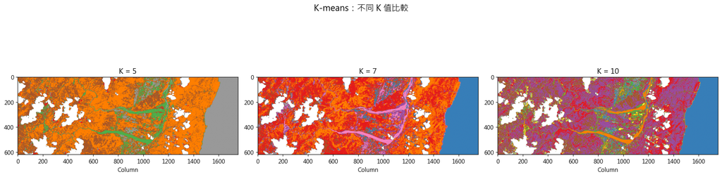

```
思考：K 值越大，分類越細緻，但過多的群組可能難以解讀。
你認為哪個 K 值最適合這個研究區域？

=================================================================
  觀察重點：注意陸地上是否有和海洋同色的像素
=================================================================
  這些陸地上的「疑似水體」像素可能是：
    1. 雲影（cloud shadow）— SCL 遮罩未完全移除的殘留
    2. 山區地形陰影 — 中央山脈東坡的自遮蔽效應
    3. 深色建物屋頂 — 20m 解析度下的混合像素

  ⚠️  這正是 K-means 的根本限制：
    非監督分類只看光譜相似度，無法區分「暗因為是水」
    和「暗因為是陰影」。後續 Lab 2 的監督式分類可以
    利用訓練樣本學到水體和陰影在 SWIR 波段的細微差異。
```

```python
# =============================================================================
# [S10] K 值比較 【COMPLETED】
# =============================================================================
# 嘗試不同的 K 值，觀察分類結果的差異

fig, axes = plt.subplots(1, 3, figsize=(18, 5))

for ax_idx, k_val in enumerate([5, 7, 10]):
    # ── COMPLETED ──
    # 對每個 k_val 執行 KMeans 分類
    # Hint: KMeans(n_clusters=k_val, random_state=42, n_init=10, max_iter=300)
    km_temp = KMeans(n_clusters=k_val, random_state=42, n_init=10, max_iter=300)
    lbl = km_temp.fit_predict(pixels_valid)
    # ── END COMPLETED ──

    # 重建分類圖並視覺化（已預先填好）
    cmap_temp = plt.cm.get_cmap("Set1", k_val)
    cm_temp = np.full(pixels.shape[0], np.nan)
    cm_temp[valid_pixel_mask] = lbl
    cm_temp = cm_temp.reshape(n_rows, n_cols)
    axes[ax_idx].imshow(cm_temp, cmap=cmap_temp, vmin=-0.5, vmax=k_val - 0.5)
    axes[ax_idx].set_title(f"K = {k_val}", fontsize=13)
    axes[ax_idx].set_xlabel("Column")

plt.suptitle("K-means：不同 K 值比較", fontsize=15, y=1.02)
plt.tight_layout()
plt.show()

print("思考：K 值越大，分類越細緻，但過多的群組可能難以解讀。")
print("你認為哪個 K 值最適合這個研究區域？")
print()
print("=" * 65)
print("  觀察重點：注意陸地上是否有和海洋同色的像素")
print("=" * 65)
print("  這些陸地上的「疑似水體」像素可能是：")
print("    1. 雲影（cloud shadow）— SCL 遮罩未完全移除的殘留")
print("    2. 山區地形陰影 — 中央山脈東坡的自遮蔽效應")
print("    3. 深色建物屋頂 — 20m 解析度下的混合像素")
print()
print("  ⚠️  這正是 K-means 的根本限制：")
print("    非監督分類只看光譜相似度，無法區分「暗因為是水」")
print("    和「暗因為是陰影」。後續 Lab 2 的監督式分類可以")
print("    利用訓練樣本學到水體和陰影在 SWIR 波段的細微差異。")
```